# Módulo 1: Fundamentos espaciales en R

**`dsn = "BASES_DE_DATOS/informacion_formato_nuevo.gpkg"`**: Es la ruta con la ubicación, nombre y extensión del archivo *GeoPackage*. Recuerda que este formato funciona como una base de datos o “caja” única donde puedes guardar múltiples mapas.

**`layer = "entidades_federativas"`**: Es el nombre específico (la “etiqueta”) que le darás a esta capa en particular dentro del archivo *GeoPackage*.

.

.

Cuando se trabaja con datos de encuestas a nivel de entidades federativas, es fundamental contar con la cartografía de los países vecinos para contextualizar geográficamente nuestra área de estudio, en este caso México. Una de las fuentes más importantes para obtener este tipo de información es la librería **`rnaturalearth`**, la cual provee mapas detallados de los límites internacionales, además de fronteras administrativas internas, líneas de costa y diversos elementos geográficos de escala global. El paquete complementario **`rnaturalearthdata`** también debe cargarse porque es el que contiene físicamente los archivos de almacenamiento con los mapas en resoluciones baja y media. Dado que la librería principal funciona únicamente como el motor de búsqueda o interfaz de conexión, requiere obligatoriamente de esta base de datos adicional para poder extraer y proyectar las formas geométricas. Dependiendo del nivel de detalle que requiera tu mapa, puedes elegir entre una resolución rápida y ligera para vistas globales, o descargar paquetes adicionales de alta definición si necesitas trazar fronteras costeras o terrestres con máxima precisión.

.

Vamos a cargar y visualizar la capa con limites internacionales de los paises

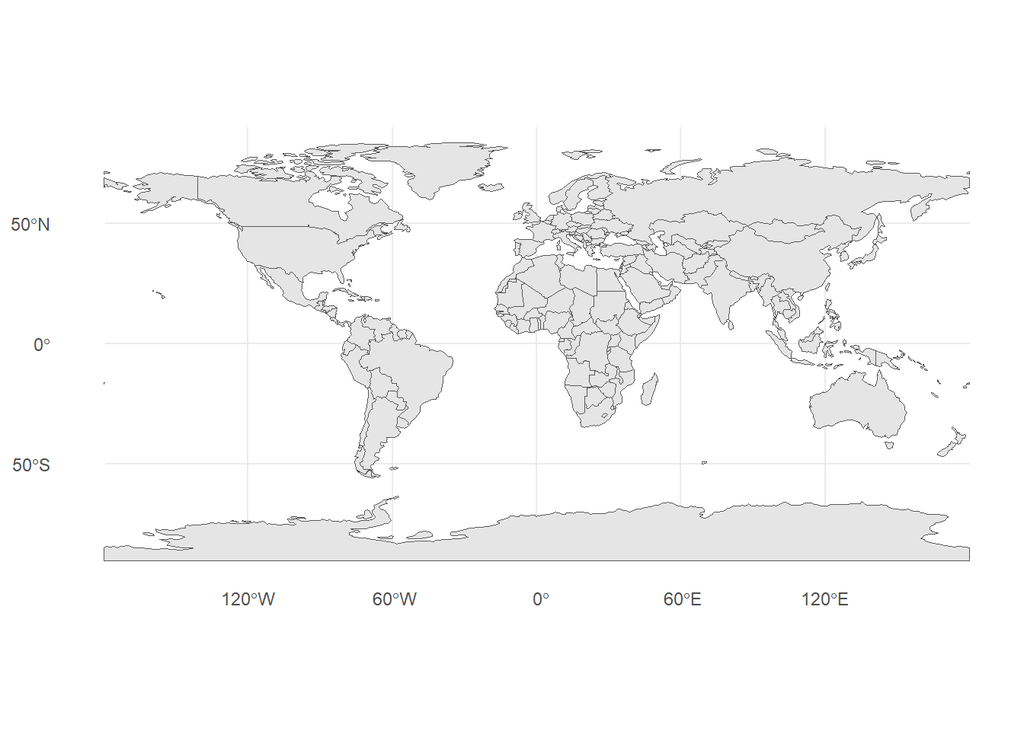

```r
# Descargar el mapa mundial en la resolución más baja (escala 110 millones) en objeto sf
paises_totales <- ne_countries(scale = 110, returnclass = "sf")
# Visualizar cartografia
ggplot() +
  geom_sf(data = paises_totales) +
  theme_minimal() # Opcional: agrega un fondo limpio al mapa
```

.

Para garantizar que el procesamiento de tu mapa sea eficiente, no desperdiciar memoria RAM y manipular los datos de forma más sencilla, se recomienda seleccionar únicamente los territorios indispensables para el análisis. Mantener un mapa con todos los países del mundo hace más lenta las operaciones de dibujo y análisis geométrico, por lo que filtrar la base de datos desde el inicio conserva tu entorno de trabajo limpio y rápido.

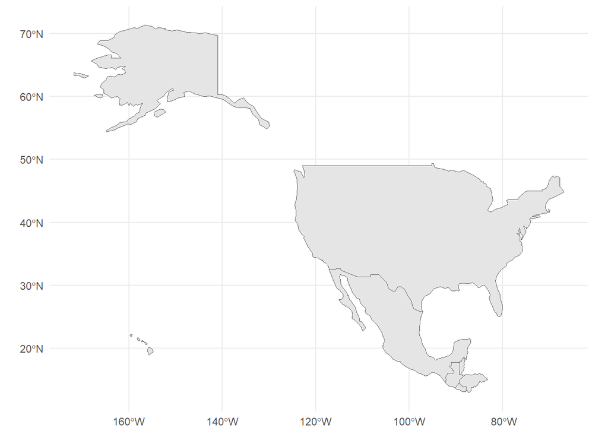

```r
# Filtrar México y sus países vecinos (incluyendo Centroamérica cercana)
paises_vecinos <- paises_totales %>%
  filter(name %in% c("Mexico", "United States of America", "Guatemala", "Belize", "Honduras", "El Salvador"))
# 4. Visualizar el filtro
ggplot() +
  geom_sf(data = paises_vecinos) +
  theme_minimal() # Opcional: agrega un fondo limpio al mapa
```

.

Ahora que tenemos esta capa geográfica disponible en la memoria de R, el siguiente paso es guardarla dentro de nuestro GeoPackage principal (donde ya se encuentran las entidades federativas). Esto nos permite conservar los mapas de forma permanente y evitar tener que descargarlos de internet cada vez que ejecutemos el código.

```r
# Guardar la información en formato GeoPackage
st_write(
  obj = paises_vecinos,
  dsn = "BASES_DE_DATOS/informacion_formato_nuevo.gpkg",
  layer = "paises_vecinos",
  append = TRUE
)
```

```
Updating layer `paises_vecinos' to data source `BASES_DE_DATOS/informacion_formato_nuevo.gpkg' using driver `GPKG'
Updating existing layer paises_vecinos
Writing 6 features with 168 fields and geometry type Multi Polygon.
```

**`obj = paises_vecinos`**: Es el objeto o variable dentro de R que contiene la información geográfica que descargamos de **`rnaturalearth`** .

**`dsn = "BASES_DE_DATOS/informacion_formato_nuevo.gpkg"`**: Es la ruta con la ubicación, nombre y extensión del archivo *GeoPackage*. Recuerda que este formato funciona como una base de datos o “caja” única donde puedes guardar múltiples mapas.

**`layer = "paises_vecinos"`**: Es el nombre específico (la “etiqueta”) que le darás a esta capa en particular dentro del archivo *GeoPackage*.

.

.

Una vez que la información ha sido almacenada de forma segura en el GeoPackage, es recomendable limpiar nuestro entorno de trabajo en R. Eliminar los objetos temporales nos permite liberar memoria RAM, mantener la interfaz ordenada. También, al limpiar el espacio de R, te verás en la necesidad de volver a importar las capas directamente desde el archivo definitivo, asegurando que el código sea reproducible.

```r
# Limpiar por completo el entorno de trabajo (borrar todos los objetos de la memoria)
rm(list = ls())
```

.

.

## Sistemas de referencia de coordenadas (CRS) y reproyección básica.

.

Ahora procederemos a importar datos en formato GeoPackage (.gpkg). Un GeoPackage funciona como una “caja de almacenamiento” o un contenedor que puede guardar muchas capas de datos vectoriales diferentes (puntos, líneas o polígonos) dentro de un solo archivo. Por esta razón, al usar st_read(), no solo debemos decirle a R dónde está el archivo, sino también especificar exactamente qué capa (layer) queremos importar.

.

Si te pasan un GeoPackage y no sabes qué información contiene, puedes consultar qué capas vectoriales contiene, usando la función st_layers(). Esto te listará todas las capas disponibles sin cargar nada a la memoria:

```r
# Consulta de la información de las capas
st_layers(
  here("BASES_DE_DATOS", "informacion_formato_nuevo.gpkg")
  )
```

```
Driver: GPKG
Available layers:
             layer_name geometry_type features fields             crs_name
1 entidades_federativas Multi Polygon      480      3 MEXICO_ITRF_2008_LCC
2        paises_vecinos Multi Polygon       90    168               WGS 84
```

.

```r
# Consulta rápida de los nombres completos de las capas
st_layers(
  here("BASES_DE_DATOS", "informacion_formato_nuevo.gpkg")
  )$name
```

```
[1] "entidades_federativas" "paises_vecinos"
```

Al usar $name después de la estructura de código de st_layers(), se extraen únicamente los nombres de las capas en formato de texto plano.

.

.

Una vez conocidos los nombres de las capas, pasamos a importar la que necesitamos. Para ello, volvemos a usar la función st_read(), pero esta vez agregamos el argumento “layer” para indicarle a R el nombre exacto de la capa que queremos extraer de la “caja de almacenamiento”:

```r
# Importamos la base cartográfica de las entidades federativas se importó bajo el nombre de cartog_ent_fed
cartog_ent_fed <- st_read(
  here("BASES_DE_DATOS", "informacion_formato_nuevo.gpkg"),
  layer = "entidades_federativas"
)
```

**`cartog_ent_fed`**

.

```r
# Importamos la base cartográfica de las paises vecinos se importó bajo el nombre de cartog_paises_vecinos
cartog_paises_vecinos <- st_read(
  here("BASES_DE_DATOS", "informacion_formato_nuevo.gpkg"),
  layer = "paises_vecinos"
)
```

**`cartog_paises_vecinos`**

.

.

**🚨 El problema invisible: Identificación de CRS y Reproyección**

Si intentas graficar estas dos capas juntas en un mismo mapa utilizando `ggplot2` en este momento, notarás que los países vecinos no aparecen o el mapa se rompe. Esto ocurre porque **las capas no hablan el mismo idioma matemático**:

- La capa de entidades federativas mide el mundo en **metros** (`Mexico ITRF2008 / LCC`).
- La capa de países vecinos mide el mundo en **grados** (`WGS 84`).

Para R, intentar juntar metros con grados en un espacio geométrico es imposible porque las cajas de delimitación (`Bounding box`) manejan escalas numéricas completamente distintas. Mientras que una capa se extiende en millones de metros, la otra solo llega hasta unas decenas de grados.

**¿Cómo lo solucionamos?**

Antes de realizar cualquier mapa combinado o análisis espacial, debemos **homogeneizar el Sistema de Referencia de Coordenadas (CRS)**. Esto implica elegir una de las dos capas como base y transformar la otra para que ambas compartan exactamente el mismo CRS mediante una técnica llamada **reproyección**.

.

**🧠 ¿Cómo funciona la asignación de CRS y la Reproyección en R?**

Para que R pueda proyectar una capa sobre otra sin errores, no es necesario que busques y escribas manualmente los complejos códigos de los sistemas de referencia. Podemos resolverlo de forma dinámica mediante dos pasos lógicos:

1. **Extraer el CRS base:** Usamos la función `st_crs()` para leer y almacenar el “idioma cartográfico” de la capa de referencia (en este caso, nuestras `entidades_federativas`).
2. **Transformar la capa destino:** Usamos la función `st_transform()`. R tomará la capa de `paises_vecinos` (que está en grados) y recalculará matemáticamente todas sus coordenadas para adaptarlas exactamente al sistema métrico de México que acabamos de extraer.

```r
#VERIFICACIÓN MANUAL: Extraer el CRS de cualquier objeto en cualquier momento
# Esto te permite checar el sistema de referencia sin depender del mensaje de carga inicial
crs_ent_fed  <- st_crs(cartog_ent_fed)
crs_paises_vecinos <- st_crs(cartog_paises_vecinos)
```

```r
# Imprimir el crs de las entidades federativas
print(crs_ent_fed)
```

```
Coordinate Reference System:
  User input: MEXICO_ITRF_2008_LCC
  wkt:
PROJCRS["MEXICO_ITRF_2008_LCC",
    BASEGEOGCRS["MEXICO_ITRF_2008",
        DATUM["International Terrestrial Reference Frame 2008",
            ELLIPSOID["GRS 1980",6378137,298.257222101,
                LENGTHUNIT["metre",1]],
            ID["EPSG",1061]],
        PRIMEM["Greenwich",0,
            ANGLEUNIT["Degree",0.0174532925199433]]],
    CONVERSION["unnamed",
        METHOD["Lambert Conic Conformal (2SP)",
            ID["EPSG",9802]],
        PARAMETER["Latitude of false origin",12,
            ANGLEUNIT["Degree",0.0174532925199433],
            ID["EPSG",8821]],
        PARAMETER["Longitude of false origin",-102,
            ANGLEUNIT["Degree",0.0174532925199433],
            ID["EPSG",8822]],
        PARAMETER["Latitude of 1st standard parallel",17.5,
            ANGLEUNIT["Degree",0.0174532925199433],
            ID["EPSG",8823]],
        PARAMETER["Latitude of 2nd standard parallel",29.5,
            ANGLEUNIT["Degree",0.0174532925199433],
            ID["EPSG",8824]],
        PARAMETER["Easting at false origin",2500000,
            LENGTHUNIT["metre",1],
            ID["EPSG",8826]],
        PARAMETER["Northing at false origin",0,
            LENGTHUNIT["metre",1],
            ID["EPSG",8827]]],
    CS[Cartesian,2],
        AXIS["easting",east,
            ORDER[1],
            LENGTHUNIT["metre",1,
                ID["EPSG",9001]]],
        AXIS["northing",north,
            ORDER[2],
            LENGTHUNIT["metre",1,
                ID["EPSG",9001]]]]
```

```r
# Imprimir el crs de los paises vecinos
print(crs_paises_vecinos)
```

```
Coordinate Reference System:
  User input: WGS 84
  wkt:
GEOGCRS["WGS 84",
    ENSEMBLE["World Geodetic System 1984 ensemble",
        MEMBER["World Geodetic System 1984 (Transit)"],
        MEMBER["World Geodetic System 1984 (G730)"],
        MEMBER["World Geodetic System 1984 (G873)"],
        MEMBER["World Geodetic System 1984 (G1150)"],
        MEMBER["World Geodetic System 1984 (G1674)"],
        MEMBER["World Geodetic System 1984 (G1762)"],
        MEMBER["World Geodetic System 1984 (G2139)"],
        MEMBER["World Geodetic System 1984 (G2296)"],
        ELLIPSOID["WGS 84",6378137,298.257223563,
            LENGTHUNIT["metre",1]],
        ENSEMBLEACCURACY[2.0]],
    PRIMEM["Greenwich",0,
        ANGLEUNIT["degree",0.0174532925199433]],
    CS[ellipsoidal,2],
        AXIS["geodetic latitude (Lat)",north,
            ORDER[1],
            ANGLEUNIT["degree",0.0174532925199433]],
        AXIS["geodetic longitude (Lon)",east,
            ORDER[2],
            ANGLEUNIT["degree",0.0174532925199433]],
    USAGE[
        SCOPE["Horizontal component of 3D system."],
        AREA["World."],
        BBOX[-90,-180,90,180]],
    ID["EPSG",4326]]
```

```r
# REPROYECCIÓN DINÁMICA: Transformar los países vecinos al CRS de México
# En lugar de escribir el código del CRS a mano, le pasamos el objeto 'crs_ent_fed'
cartog_reproy_paises_vecinos <- st_transform(cartog_paises_vecinos, crs = crs_ent_fed)
```

```r
# COMPROBACIÓN MANUAL: Verificar que ahora ambos objetos comparten el mismo CRS
st_crs(cartog_reproy_paises_vecinos) == st_crs(cartog_ent_fed) # Debería devolver TRUE
```

```
[1] TRUE
```

**💡 Puntos clave:**

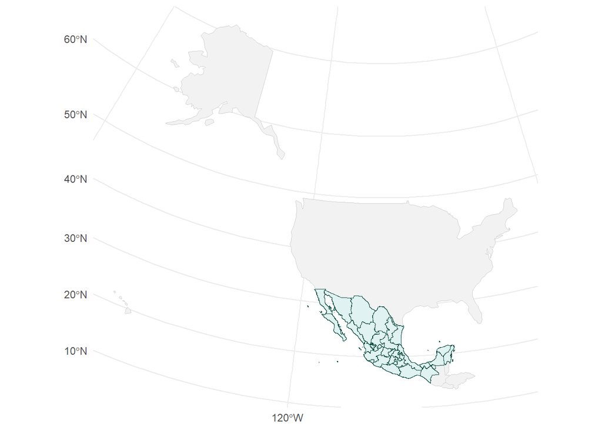

```r
# COMPROBACIÓN GRÁFICA
ggplot() +
  # Capa de fondo: Países vecinos en gris claro
  geom_sf(
    data = cartog_reproy_paises_vecinos,
    fill = "#F2F2F2",
    color = "#D0D0D0") +

  # Capa principal: Entidades federativas con bordes definidos
  geom_sf(
    data = cartog_ent_fed,
    fill = "#E0F2F1",
    color = "#004D40",
    linewidth = 0.3) +

  # Aplicar un estilo limpio y estético
  theme_minimal()
```

**💡Nota**

- **El orden de las capas importa:** R dibuja el código en forma de capas (como hojas de papel puestas una sobre otra). La primera función `geom_sf()` que escribes queda abajo, y las siguientes se van encimando.

.

**🔍 El “Efecto Zoom” al combinar mapas: ¿Por qué México se ve tan pequeño?**

Cuando logramos que la capa de países vecinos y la de entidades federativas compartan la misma proyección (`MEXICO_ITRF_2008_LCC`), R ya puede dibujarlas juntas en el mismo plano matemático. Sin embargo, surge un nuevo reto visual.

**La solución: Crear una “Ventana de Enfoque” con `coord_sf()` y `st_bbox()`**

Para solucionar esto sin tener que recortar o borrar físicamente los mapas de nuestros vecinos, recurrimos a un truco fotográfico: **ajustar el lente de la cámara**. Le diremos a R que mantenga a los países vecinos dibujados de fondo, pero que enfoque la pantalla únicamente en los límites de México.

Esto lo logramos combinando dos herramientas:

1. **`st_bbox()`** (Bounding Box / Caja de Delimitación): Es una función que calcula de forma automática los cuatro puntos extremos de un mapa (el punto más al norte, al sur, al este y al oeste). Al aplicarla sobre las entidades federativas (`st_bbox(cartog_ent_fed)`), obtenemos las coordenadas exactas de las “esquinas” territoriales de México.
2. **`coord_sf(xlim, ylim)`**: Es la función de `ggplot2` encargada de controlar los límites visuales de la pantalla. Al pasarle los valores extremos (`xmin`, `xmax`, `ymin`, `ymax`) que calculó `st_bbox()`, fijamos las coordenadas máximas del plano horizontal (X) y vertical (Y).

El resultado es mágico: los países vecinos siguen existiendo en el mapa para dar contexto en las fronteras, pero la visualización se recorta de forma exacta al tamaño de la República Mexicana, manteniendo el protagonismo en nuestra área de estudio.

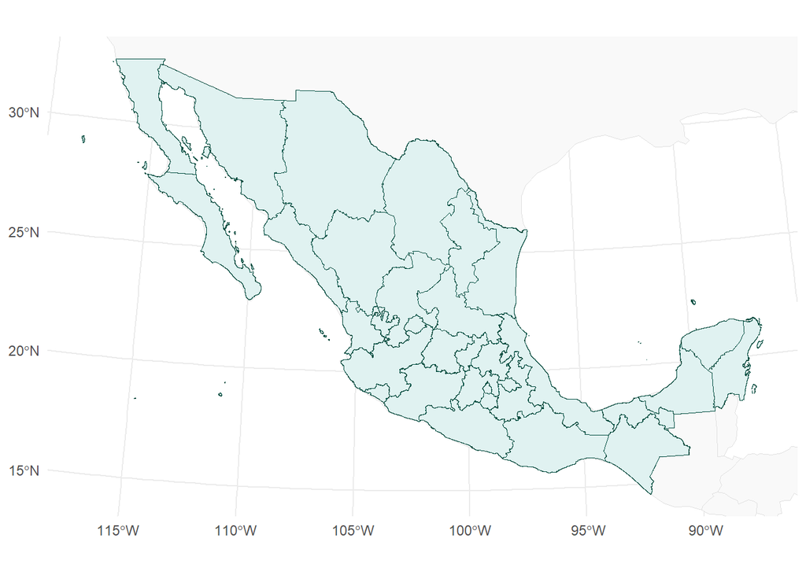

```r
ggplot() +
  # Dibujamos los países vecinos al fondo (gris claro)
  geom_sf(
    data = cartog_reproy_paises_vecinos,
    fill = "#F9F9F9",
    color = "#E0E0E0") +

  # Dibujamos las entidades federativas encima (color menta suave)
  geom_sf(data = cartog_ent_fed, fill = "#E0F2F1", color = "#004D40", linewidth = 0.3) +

  # AJUSTE DEL LENTE: Enfocar la pantalla exclusivamente en el cuadro de México
  coord_sf(
    xlim = c(
      st_bbox(cartog_ent_fed)[["xmin"]],
      st_bbox(cartog_ent_fed)[["xmax"]]
      ),
    ylim = c(st_bbox(cartog_ent_fed)[["ymin"]],
             st_bbox(cartog_ent_fed)[["ymax"]])
    ) +

  # Estilo final del mapa
  theme_minimal()
```

.

**🗺️ ¿El mapa quedó muy ceñido o recortado?**

A veces, usar st_bbox() de forma directa puede dejar los bordes del mapa demasiado pegados a las fronteras, provocando que se corten los nombres de los estados o los detalles costeros.

Como nuestro mapa está proyectado en metros (`MEXICO_ITRF_2008_LCC`), puedes expandir la ventana visual sumando o restando metros directamente a los límites dentro de coord_sf().

Mira cómo puedes agregarle un margen (por ejemplo, 50,000 metros o 50 km) a cada lado para que el mapa respire:

.

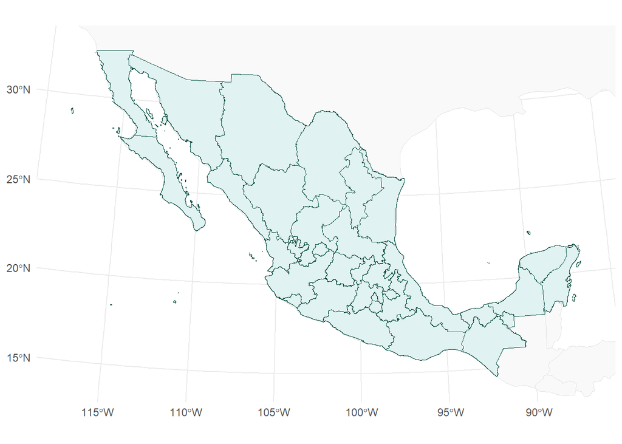

```r
ggplot() +
  # Dibujamos los países vecinos al fondo (gris claro)
  geom_sf(
    data = cartog_reproy_paises_vecinos,
    fill = "#F9F9F9",
    color = "#E0E0E0") +

  # Dibujamos las entidades federativas encima (color menta suave)
  geom_sf(data = cartog_ent_fed, fill = "#E0F2F1", color = "#004D40", linewidth = 0.3) +

  # AJUSTE DEL LENTE: Enfocar la pantalla exclusivamente en el cuadro de México
# AJUSTE DEL LENTE: Enfocar la pantalla exclusivamente en el cuadro de México
  coord_sf(
    xlim = c(
      st_bbox(cartog_ent_fed)[["xmin"]] - 50000,
      st_bbox(cartog_ent_fed)[["xmax"]] + 50000
      ),
    ylim = c(st_bbox(cartog_ent_fed)[["ymin"]] - 50000,
             st_bbox(cartog_ent_fed)[["ymax"]] + 50000)
    ) +
  # Estilo final del mapa
  theme_minimal()
```

.

**La regla de oro para ajustar coordenadas:**

.

Para los lados (X): Restar te mueve a la izquierda (Oeste); sumar te mueve a la derecha (Este). Para arriba/abajo (Y): Restar te mueve hacia abajo (Sur); sumar te mueve hacia arriba (Norte).

.

.

**¡Gracias por completar el Módulo 1!** Hemos abordado con éxito los **fundamentos espaciales en R**, construyendo una base sólida para lo que viene. Antes de dar el salto al siguiente nivel, es fundamental dejar nuestro entorno de trabajo impecable. En programación, empezar con un entorno limpio evita conflictos de datos y asegura que tus próximos scripts corran a la perfección.

```r
# Limpiar por completo el entorno de trabajo (borrar todos los objetos de la memoria)
rm(list = ls())
```

.

.